# Homework_04

Joe Webb

2/9/2022

Return to Home Page

# Question 1

Suppose x = 1.1, a = 2.2, and b = 3.3. Assign each expression to the value of the variable z and print the value stored in z.

```r
x <- 1.1
a <- 2.2
b <- 3.3
```

### 1a

```r
q1a<-x^a^b
print(q1a)
```

```
## [1] 3.61714
```

### 1b

```r
q1b<-(x^a)^b
print(q1b)
```

```
## [1] 1.997611
```

### 1c

```r
q1c<-3*x^3+2*x^2+1
print(q1c)
```

```
## [1] 7.413
```

# Question 2

Using the `rep` and `seq` functions, create the following vectors:

### 2a

(1,2,3,4,5,6,7,8,7,6,5,4,3,2,1)

```r
q2b<-c(seq(from = 1, to = 8, by = 1), seq(from = 7, to = 1))
print(q2b)
```

```
##  [1] 1 2 3 4 5 6 7 8 7 6 5 4 3 2 1
```

### 2b

(1,2,2,3,3,3,4,4,4,4,5,5,5,5,5)

```r
q2b<-c(1,rep(2, 2), rep(3,3), rep(4, 4), rep(5,5))
print(q2b)
```

```
##  [1] 1 2 2 3 3 3 4 4 4 4 5 5 5 5 5
```

### 2c

(5,4,4,3,3,3,2,2,2,2,1,1,1,1,1)

```r
q2c<-c(5, rep(4,2), rep(3,3), rep(2,4), rep(1,5))
print(q2c)
```

```
##  [1] 5 4 4 3 3 3 2 2 2 2 1 1 1 1 1
```

# Question 3

Create a vector of two random uniform numbers. In a spatial map, these can be interpreted as x and y coordinates that give the location of an individual (such as a marked forest tree in a plot that has been mapped). Using one of R’s inverse trigonometry functions (asin(), acos(), or atan()), convert these numbers into polar coordinates.

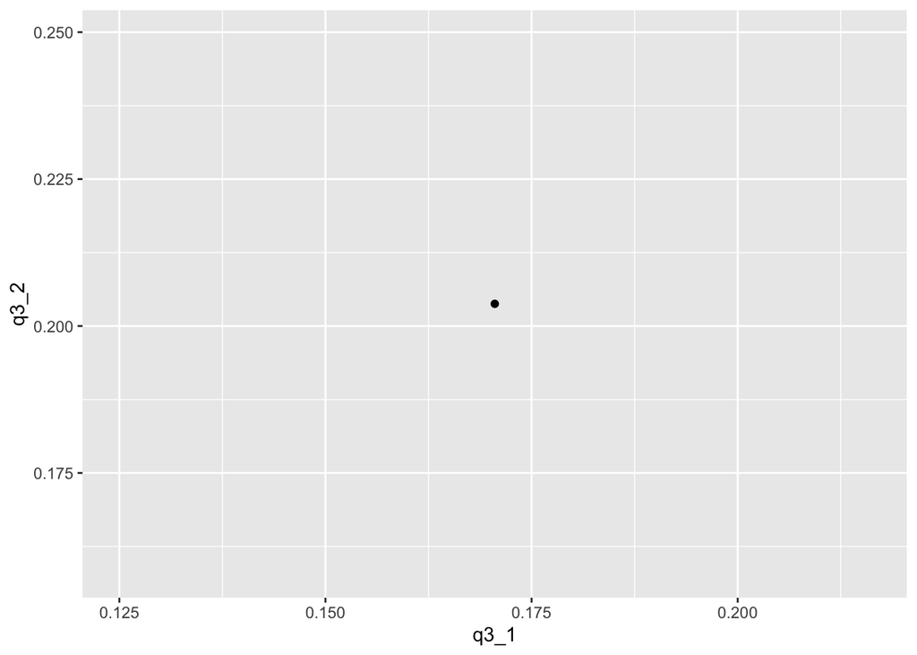

```r
# Generating two random values between 0 and 1
q3_1<-runif(1) #this will be our x-value
q3_2<-runif(1) #this will be out y-value

# Plotting two points
library(ggplot2)
qplot(x=q3_1,y=q3_2)
```

```r
# Converting to polar points
theta<-(atan(q3_2/q3_1)^-1)
print(theta)
```

```
## [1] 1.144205
```

```r
r<-(q3_1^2+q3_2^2)
print(r)
```

```
## [1] 0.07060886
```

# Question 4

Create a vector `queue <- c("sheep", "fox", "owl", "ant")` where `queue` represents the animals that are lined up to enter Noah’s Ark, with the sheep at the front of the line. Using R expressions, update `queue` as:

```r
queue <- c("sheep", "fox", "owl", "ant")
```

### 4a

the serpent arrives and gets in line;

```r
q4a<-append(queue, "serpent", after = 5)
print(q4a)
```

```
## [1] "sheep"   "fox"     "owl"     "ant"     "serpent"
```

### 4b

the sheep enters the ark;

```r
typeof(q4a)
```

```
## [1] "character"
```

```r
q4b <- q4a[! q4a %in% "sheep"]

print(q4b)
```

```
## [1] "fox"     "owl"     "ant"     "serpent"
```

### 4c

the donkey arrives and talks his way to the front of the line;

```r
q4c<-append(q4b, "donkey", after = 0)

print(q4c)
```

```
## [1] "donkey"  "fox"     "owl"     "ant"     "serpent"
```

### 4d

the serpent gets impatient and leaves;

```r
q4d <- q4c[! q4c %in% "serpent"]
print(q4d)
```

```
## [1] "donkey" "fox"    "owl"    "ant"
```

### 4e

the owl gets bored and leaves;

```r
q4e <-q4d[! q4d %in% "owl"]
print(q4e)
```

```
## [1] "donkey" "fox"    "ant"
```

### 4f

the aphid arrives and the ant invites him to cut in line.

```r
q4f<- append(q4e, "aphid", after = 2)
print(q4f)
```

```
## [1] "donkey" "fox"    "aphid"  "ant"
```

### 4g

Finally, determine the position of the aphid in the line.

```r
which(q4f=="aphid")
```

```
## [1] 3
```

# Question 5

Use R to create a vector of all of the integers from 1 to 100 that are not divisible by 2, 3, or 7.

```r
vector <- (1:100)
q5<-which(vector %%2!=0 & vector %%3!=0 & vector %%7!=0)

print(q5)
```

```
##  [1]  1  5 11 13 17 19 23 25 29 31 37 41 43 47 53 55 59 61 65 67 71 73 79 83 85
## [26] 89 95 97
```